# UNTITLED FINAL

## **HEAT WORLD MAP**

INSIGHTS:

- Higher careseeking rates are concentrated in Latin America, Southeast Asia, and Eastern Europe, reflecting stronger healthcare access and awareness.
- Sub-Saharan Africa and parts of South Asia show consistently low rates, exposing severe healthcare access gaps and systemic inequalities.
- Missing or incomplete data in several countries highlights critical weaknesses in health reporting and surveillance systems.
- Some middle-income countries still report low careseeking, suggesting that economic growth alone does not guarantee healthcare utilization.

```python
# Calculate country means for averaged plots
country_means = merged_df.dropna().groupby('country_x').mean(numeric_only =True).reset_index()
```

```python
country_means_obs = indicator_total.groupby(['country', 'alpha_3_code'])['obs_value'].mean().reset_index()
# Rename the 'obs_value' column to 'Care-Seeking Percentage'
country_means_obs = country_means_obs.rename(columns={'obs_value': 'Care-Seeking Percentage'})
# Round off the 'Care-Seeking Percentage' values to 2 decimal places
country_means_obs['Care-Seeking Percentage'] = country_means_obs['Care-Seeking Percentage'].round(2)
fig = px.choropleth(
    country_means_obs,
    locations='alpha_3_code',
    color='Care-Seeking Percentage',  # Use the new column name
    hover_name='country',
    hover_data={'alpha_3_code': False,  # Hide alpha_3_code from hover data
                'Care-Seeking Percentage': True}, # Keep care seeking percentage
    color_continuous_scale=px.colors.sequential.Plasma,
    title='CHILD RESPIRATORY ILLNESS: A CROSS-NATIONAL COMPARISON'
)

fig.update_layout(
    coloraxis_colorbar=dict(
        title="Care Seeking %",  # <-- Change this text!
        title_side="right",            # Make the title above the color bar
        title_font=dict(size=14),    # Optional: control font size
    ),
)
fig.show()
```

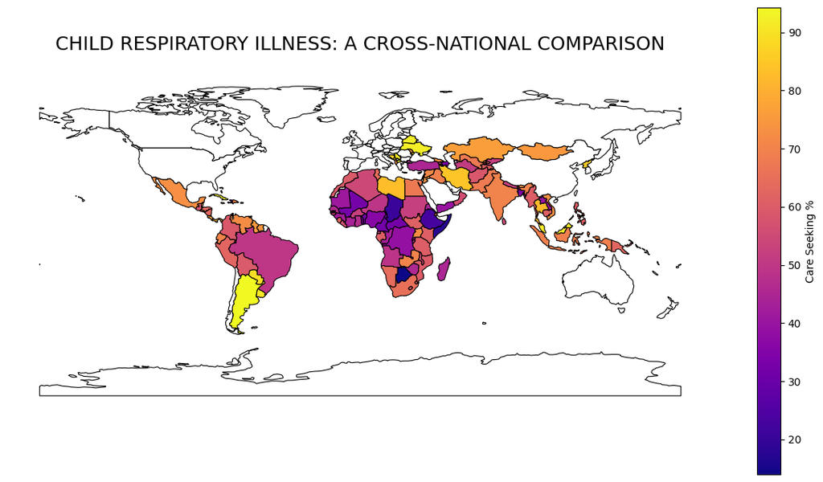

```python
import geopandas as gpd
import matplotlib.pyplot as plt

# Load the world map
world = gpd.read_file(gpd.datasets.get_path('naturalearth_lowres'))

# Merge your data with world map
merged = world.merge(country_means_obs, left_on='iso_a3', right_on='alpha_3_code', how='left')

# Plot
fig, ax = plt.subplots(1, 1, figsize=(15, 8))

merged.plot(
    column='Care-Seeking Percentage',
    cmap='plasma',        # Color scale
    linewidth=0.8,
    ax=ax,
    edgecolor='black',    # Black country borders
    legend=True,
    missing_kwds={
        "color": "white",  # Countries without data will be white
        "edgecolor": "black",
        "hatch": "",    # Optional: add a hatch pattern if you want
        "label": "No Data"
    },
    legend_kwds={'label': "Care Seeking %", 'orientation': "vertical"}
)

# Title and remove axis
ax.set_title('CHILD RESPIRATORY ILLNESS: A CROSS-NATIONAL COMPARISON', fontdict={'fontsize': 18}, pad=20)
ax.axis('off')

plt.show()
```

KEY HIGHLIGHT:

Careseeking for ARI is deeply tied to geography, health infrastructure, and social factors, revealing that a child's survival often depends more on their birthplace than on the treatability of the disease. To address these inequalities, efforts must focus on expanding healthcare access, strengthening community health programs, and improving data collection for better-informed interventions.